# PROBLEM :1 WHOLESALE CUSTOMER ANALYSIS

```python
import pandas as pd
import numpy as np
import matplotlib
import matplotlib.pyplot as plt
import seaborn as sns
import scipy.stats as stats
import statsmodels.stats.api as sm
import copy
```

```python
import os
```

```python
os.getcwd()
```

```
'C:\\Users\\rvee'
```

```python
os.chdir('C:/Users/rvee/Downloads')
```

```python
data= pd.read_csv('Wholesale+Customers+Data.csv')
```

```python
data
```

|  | Buyer/Spender | Channel | Region | Fresh | Milk | Grocery | Frozen | Detergents_Paper | Delicatessen |
| --- | --- | --- | --- | --- | --- | --- | --- | --- | --- |
| 0 | 1 | Retail | Other | 12669 | 9656 | 7561 | 214 | 2674 | 1338 |
| 1 | 2 | Retail | Other | 7057 | 9810 | 9568 | 1762 | 3293 | 1776 |
| 2 | 3 | Retail | Other | 6353 | 8808 | 7684 | 2405 | 3516 | 7844 |
| 3 | 4 | Hotel | Other | 13265 | 1196 | 4221 | 6404 | 507 | 1788 |
| 4 | 5 | Retail | Other | 22615 | 5410 | 7198 | 3915 | 1777 | 5185 |
| ... | ... | ... | ... | ... | ... | ... | ... | ... | ... |
| 435 | 436 | Hotel | Other | 29703 | 12051 | 16027 | 13135 | 182 | 2204 |
| 436 | 437 | Hotel | Other | 39228 | 1431 | 764 | 4510 | 93 | 2346 |
| 437 | 438 | Retail | Other | 14531 | 15488 | 30243 | 437 | 14841 | 1867 |
| 438 | 439 | Hotel | Other | 10290 | 1981 | 2232 | 1038 | 168 | 2125 |
| 439 | 440 | Hotel | Other | 2787 | 1698 | 2510 | 65 | 477 | 52 |

440 rows × 9 columns

Summary of Dataset

```python
data.info()
```

```
<class 'pandas.core.frame.DataFrame'>
RangeIndex: 440 entries, 0 to 439
Data columns (total 9 columns):
 #   Column            Non-Null Count  Dtype
---  ------            --------------  -----
 0   Buyer/Spender     440 non-null    int64
 1   Channel           440 non-null    object
 2   Region            440 non-null    object
 3   Fresh             440 non-null    int64
 4   Milk              440 non-null    int64
 5   Grocery           440 non-null    int64
 6   Frozen            440 non-null    int64
 7   Detergents_Paper  440 non-null    int64
 8   Delicatessen      440 non-null    int64
dtypes: int64(7), object(2)
memory usage: 31.1+ KB
```

Checking for missing values

```python
data.isnull()
```

|  | Buyer/Spender | Channel | Region | Fresh | Milk | Grocery | Frozen | Detergents_Paper | Delicatessen |
| --- | --- | --- | --- | --- | --- | --- | --- | --- | --- |
| 0 | False | False | False | False | False | False | False | False | False |
| 1 | False | False | False | False | False | False | False | False | False |
| 2 | False | False | False | False | False | False | False | False | False |
| 3 | False | False | False | False | False | False | False | False | False |
| 4 | False | False | False | False | False | False | False | False | False |
| ... | ... | ... | ... | ... | ... | ... | ... | ... | ... |
| 435 | False | False | False | False | False | False | False | False | False |
| 436 | False | False | False | False | False | False | False | False | False |
| 437 | False | False | False | False | False | False | False | False | False |
| 438 | False | False | False | False | False | False | False | False | False |
| 439 | False | False | False | False | False | False | False | False | False |

440 rows × 9 columns

```python
data.isnull().sum()
```

```
Buyer/Spender       0
Channel             0
Region              0
Fresh               0
Milk                0
Grocery             0
Frozen              0
Detergents_Paper    0
Delicatessen        0
dtype: int64
```

```python
del data['Buyer/Spender']
```

Q1.1 Use methods of descriptive statistics to summarize data. Which Region and which Channel spent the most? Which Region and which Channel spent the least?

```python
data.describe(include='all').T
```

|  | count | unique | top | freq | mean | std | min | 25% | 50% | 75% | max |
| --- | --- | --- | --- | --- | --- | --- | --- | --- | --- | --- | --- |
| Channel | 440 | 2 | Hotel | 298 | NaN | NaN | NaN | NaN | NaN | NaN | NaN |
| Region | 440 | 3 | Other | 316 | NaN | NaN | NaN | NaN | NaN | NaN | NaN |
| Fresh | 440.0 | NaN | NaN | NaN | 12000.297727 | 12647.328865 | 3.0 | 3127.75 | 8504.0 | 16933.75 | 112151.0 |
| Milk | 440.0 | NaN | NaN | NaN | 5796.265909 | 7380.377175 | 55.0 | 1533.0 | 3627.0 | 7190.25 | 73498.0 |
| Grocery | 440.0 | NaN | NaN | NaN | 7951.277273 | 9503.162829 | 3.0 | 2153.0 | 4755.5 | 10655.75 | 92780.0 |
| Frozen | 440.0 | NaN | NaN | NaN | 3071.931818 | 4854.673333 | 25.0 | 742.25 | 1526.0 | 3554.25 | 60869.0 |
| Detergents_Paper | 440.0 | NaN | NaN | NaN | 2881.493182 | 4767.854448 | 3.0 | 256.75 | 816.5 | 3922.0 | 40827.0 |
| Delicatessen | 440.0 | NaN | NaN | NaN | 1524.870455 | 2820.105937 | 3.0 | 408.25 | 965.5 | 1820.25 | 47943.0 |

```python
data_spending=copy.deepcopy(data)
data_spending['Spending'] =data['Fresh']+data['Milk']+data['Grocery']+data['Frozen']+data['Detergents_Paper']+data['Delicatessen']
data_spending
```

|  | Channel | Region | Fresh | Milk | Grocery | Frozen | Detergents_Paper | Delicatessen | Spending |
| --- | --- | --- | --- | --- | --- | --- | --- | --- | --- |
| 0 | Retail | Other | 12669 | 9656 | 7561 | 214 | 2674 | 1338 | 34112 |
| 1 | Retail | Other | 7057 | 9810 | 9568 | 1762 | 3293 | 1776 | 33266 |
| 2 | Retail | Other | 6353 | 8808 | 7684 | 2405 | 3516 | 7844 | 36610 |
| 3 | Hotel | Other | 13265 | 1196 | 4221 | 6404 | 507 | 1788 | 27381 |
| 4 | Retail | Other | 22615 | 5410 | 7198 | 3915 | 1777 | 5185 | 46100 |
| ... | ... | ... | ... | ... | ... | ... | ... | ... | ... |
| 435 | Hotel | Other | 29703 | 12051 | 16027 | 13135 | 182 | 2204 | 73302 |
| 436 | Hotel | Other | 39228 | 1431 | 764 | 4510 | 93 | 2346 | 48372 |
| 437 | Retail | Other | 14531 | 15488 | 30243 | 437 | 14841 | 1867 | 77407 |
| 438 | Hotel | Other | 10290 | 1981 | 2232 | 1038 | 168 | 2125 | 17834 |
| 439 | Hotel | Other | 2787 | 1698 | 2510 | 65 | 477 | 52 | 7589 |

440 rows × 9 columns

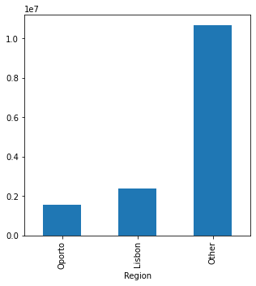

```python
plt.figure(figsize=(5,5))
data_spending.groupby('Region').sum()['Spending'].sort_values(ascending = True).plot(kind = 'bar')
```

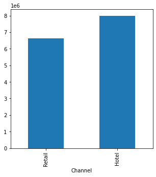

```python
plt.figure(figsize=(5,5))
data_spending.groupby('Channel').sum()['Spending'].sort_values(ascending = True).plot(kind = 'bar')
```

Q1.2 There are 6 different varieties of items that are considered. Describe and comment/explain all the varieties across Region and Channel? Provide a detailed justification for your answer.

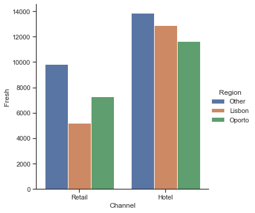

```python
sns.set(style="ticks", color_codes=True)
sns.catplot(x="Channel", y="Fresh", hue ="Region", kind="bar", ci=None, data=data)
```

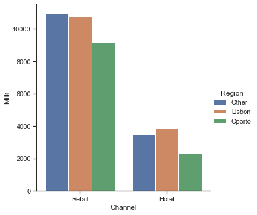

```python
sns.set(style="ticks", color_codes=True)
sns.catplot(x="Channel", y="Milk", hue ="Region", kind="bar", ci=None, data=data)
```

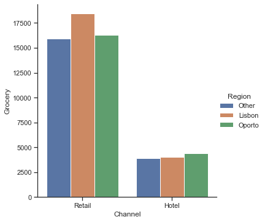

```python
sns.set(style="ticks", color_codes=True)
sns.catplot(x="Channel", y="Grocery", hue ="Region", kind="bar", ci=None, data=data)
```

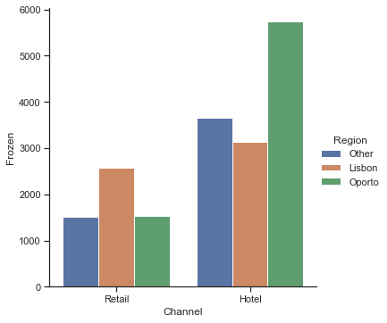

```python
sns.set(style="ticks", color_codes=True)
sns.catplot(x="Channel", y="Frozen", hue ="Region", kind="bar", ci=None, data=data)
```

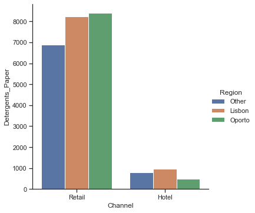

```python
sns.set(style="ticks", color_codes=True)
sns.catplot(x="Channel", y="Detergents_Paper", hue ="Region", kind="bar", ci=None, data=data)
```

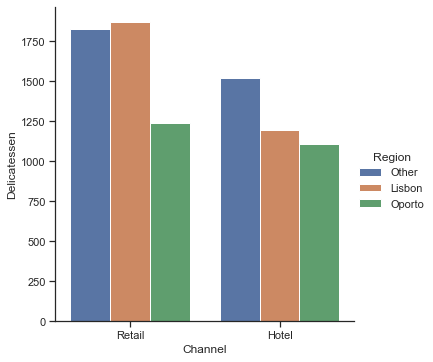

```python
sns.set(style="ticks", color_codes=True)
sns.catplot(x="Channel", y="Delicatessen", hue ="Region", kind="bar", ci=None, data=data)
```

Q1.3 On the basis of a descriptive measure of variability, which item shows the most inconsistent behaviour? Which items show the least inconsistent behaviour?

```python
cv_fresh = np.std(data['Fresh']) / np.mean(data['Fresh'])
cv_fresh
```

```
1.0527196084948245
```

```python
cv_milk = np.std(data['Milk']) / np.mean(data['Milk'])
cv_milk
```

```
1.2718508307424503
```

```python
cv_grocery = np.std(data['Grocery']) / np.mean(data['Grocery'])
cv_grocery
```

```
1.193815447749267
```

```python
cv_frozen = np.std(data['Frozen']) / np.mean(data['Frozen'])
cv_frozen
```

```
1.5785355298607762
```

```python
cv_detergents_paper = np.std(data['Detergents_Paper']) / np.mean(data['Detergents_Paper'])
cv_detergents_paper
```

```
1.6527657881041729
```

```python
cv_delicatessen = np.std(data['Delicatessen']) / np.mean(data['Delicatessen'])
cv_delicatessen
```

```
1.8473041039189306
```

Q1.4 Are there any outliers in the data? Back up your answer with a suitable plot/technique with the help of detailed comments.

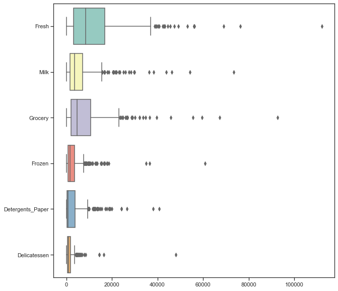

```python
plt.figure(figsize=(10,10))
sns.boxplot(data=data, orient="h", palette="Set3")
```

# PROBLEM 2

## 2.1. For this data, construct the following contingency tables (Keep Gender as row variable)

```python
df= pd.read_csv('Survey-1.csv')
df
```

|  | ID | Gender | Age | Class | Major | Grad Intention | GPA | Employment | Salary | Social Networking | Satisfaction | Spending | Computer | Text Messages |
| --- | --- | --- | --- | --- | --- | --- | --- | --- | --- | --- | --- | --- | --- | --- |
| 0 | 1 | Female | 20 | Junior | Other | Yes | 2.9 | Full-Time | 50.0 | 1 | 3 | 350 | Laptop | 200 |
| 1 | 2 | Male | 23 | Senior | Management | Yes | 3.6 | Part-Time | 25.0 | 1 | 4 | 360 | Laptop | 50 |
| 2 | 3 | Male | 21 | Junior | Other | Yes | 2.5 | Part-Time | 45.0 | 2 | 4 | 600 | Laptop | 200 |
| 3 | 4 | Male | 21 | Junior | CIS | Yes | 2.5 | Full-Time | 40.0 | 4 | 6 | 600 | Laptop | 250 |
| 4 | 5 | Male | 23 | Senior | Other | Undecided | 2.8 | Unemployed | 40.0 | 2 | 4 | 500 | Laptop | 100 |
| ... | ... | ... | ... | ... | ... | ... | ... | ... | ... | ... | ... | ... | ... | ... |
| 57 | 58 | Female | 21 | Senior | International Business | No | 2.4 | Part-Time | 40.0 | 1 | 3 | 1000 | Laptop | 10 |
| 58 | 59 | Female | 20 | Junior | CIS | No | 2.9 | Part-Time | 40.0 | 2 | 4 | 350 | Laptop | 250 |
| 59 | 60 | Female | 20 | Sophomore | CIS | No | 2.5 | Part-Time | 55.0 | 1 | 4 | 500 | Laptop | 500 |
| 60 | 61 | Female | 23 | Senior | Accounting | Yes | 3.5 | Part-Time | 30.0 | 2 | 3 | 490 | Laptop | 50 |
| 61 | 62 | Female | 23 | Senior | Economics/Finance | No | 3.2 | Part-Time | 70.0 | 2 | 3 | 250 | Laptop | 0 |

62 rows × 14 columns

```python
df.info()
```

```
<class 'pandas.core.frame.DataFrame'>
RangeIndex: 62 entries, 0 to 61
Data columns (total 14 columns):
 #   Column             Non-Null Count  Dtype
---  ------             --------------  -----
 0   ID                 62 non-null     int64
 1   Gender             62 non-null     object
 2   Age                62 non-null     int64
 3   Class              62 non-null     object
 4   Major              62 non-null     object
 5   Grad Intention     62 non-null     object
 6   GPA                62 non-null     float64
 7   Employment         62 non-null     object
 8   Salary             62 non-null     float64
 9   Social Networking  62 non-null     int64
 10  Satisfaction       62 non-null     int64
 11  Spending           62 non-null     int64
 12  Computer           62 non-null     object
 13  Text Messages      62 non-null     int64
dtypes: float64(2), int64(6), object(6)
memory usage: 6.9+ KB
```

2.1.1. Gender and Major

```python
pd.crosstab(df['Gender'],df['Major'] )
```

| Major Gender | Accounting | CIS | Economics/Finance | International Business | Management | Other | Retailing/Marketing | Undecided |
| --- | --- | --- | --- | --- | --- | --- | --- | --- |
| Female | 3 | 3 | 7 | 4 | 4 | 3 | 9 | 0 |
| Male | 4 | 1 | 4 | 2 | 6 | 4 | 5 | 3 |

2.1.2. Gender and Grad Intention

```python
pd.crosstab(df['Gender'],df['Grad Intention'] )
```

| Grad Intention Gender | No | Undecided | Yes |
| --- | --- | --- | --- |
| Female | 9 | 13 | 11 |
| Male | 3 | 9 | 17 |

2.1.3. Gender and Employment

```python
pd.crosstab(df['Gender'],df['Employment'] )
```

| Employment Gender | Full-Time | Part-Time | Unemployed |
| --- | --- | --- | --- |
| Female | 3 | 24 | 6 |
| Male | 7 | 19 | 3 |

2.1.4. Gender and Computer

```python
pd.crosstab(df['Gender'],df['Computer'] )
```

| Computer Gender | Desktop | Laptop | Tablet |
| --- | --- | --- | --- |
| Female | 2 | 29 | 2 |
| Male | 3 | 26 | 0 |

## 2.2. Assume that the sample is representative of the population of CMSU. Based on the data, answer the following question:

2.2.1. What is the probability that a randomly selected CMSU student will be male?

```python
df['Gender'].value_counts()
```

```
Female    33
Male      29
Name: Gender, dtype: int64
```

```python
print('Probability that a randomly selected candidate will be male:',29/len(df['Gender']))
```

```
Probability that a randomly selected candidate will be male: 0.46774193548387094
```

2.2.2What is the probability that a randomly selected CMSU student will be female?

```python
print('Probability that a randomly selected candidate will be female:',33/len(df['Gender']))
```

```
Probability that a randomly selected candidate will be female: 0.532258064516129
```